# Module 8

Laura Brubaker-Wittman

9/24/2019

# Probabilities and Distributions

## Objectives

The objective of this module is to begin our discussion of statistical inference from a frequentist/classical statistics approach. Doing so means that we need to cover basics of probability and distributions.

## Recap of Important Terms and Concepts

- **Population** - includes **all** of the elements from a set of data = *N*
- **Sample** - one or more observations from a population = *n*
- **Parameter** - a measurable characteristic of a *population*
- **Statistic** - a measurable characteristic of a *sample*

When we do **statistical inference** we are basically trying to draw conclusions about a *population* based on measurements from a noisy *sample* or trying to evaluate whether it is reasonable to assume that our sample is drawn from a particular population.

This process of trying to draw conclusions is complicated by the fact that…

- Our sample may be *biased*, *non-random*, or *non-representantive* in some way
- There may be unknown or unobserved variables that impact how the sample is related to the population
- The assumptions we make about the population that our sample is drawn from might not be correct

*All of these are common in primatological data and should be carefully considered when performing analyses and choosing statistical tests to run!*

## Probability

The term **probability** is applied to **population level** variables that describe the magnitude of chance associated with particular observations or event. Probabilities summarize the relative frequencies of possible outcomes.Probabilities are properties of **distributions**. Probabilities vary between zero and one. Outcomes that are impossible have *Pr = 0*, those that are certain have *Pr = 1*.

Example: if we roll a (fair) die, there are 6 possible outcomes, each has a probability of occurring of 1 in 6. This is referred to as a *frequentist* or *classical* way of thinking about the probability of different outcomes: the relative frequency with which an event occurs over numerous identical, objective trials.

**Example: Rolling a Die**

We will use the {manipulate} package and the sample() function to explore the effects of sample size on estimates of the probability of different outcomes. The probability of each outcome (rolling a “1”, “2”,…, “6”) is 1 in 6, but our estimate of the probability of each possible outcome will change with sample size.

**n=slider(0, 10000, initial=100, step=100)**

```
library(manipulate)
outcomes <- c(1,2,3,4,5,6)
manipulate(
    hist(sample(outcomes, n, replace = TRUE),
         breaks=c(0.5,1.5,2.5,3.5,4.5,5.5,6.5),
         probability = TRUE,
         main = paste("Histogram of Outcomes of ", n, " Die Rolls", sep=""),
         xlab = "roll",
         ylab = "probability"),
    n=slider(0, 10000, initial=100, step=100)
)
```

*Note: I was unable to run this code in R Markdown html rendering because manipulate() must be run in R Studio. I am assuming because of the slider code.*

## *CHALLENGES*

**CHALLENGE 1**

Write a function to simulate rolling a die where you pass the number of rolls as an argument. Then, use your function to simulate rolling two dice 1000 times and take the sum of the rolls. Plot a histogram of those results.

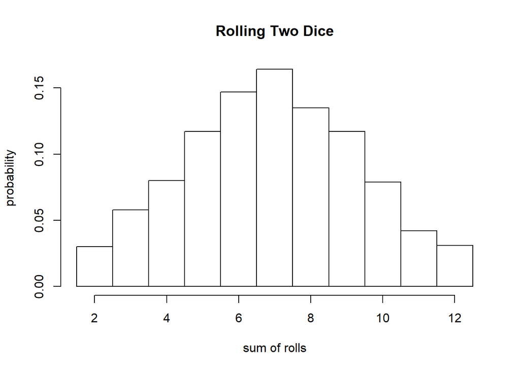

```r
nrolls <- 1000
roll <- function(x) {sample(1:6, x, replace = TRUE)}
two_dice <- roll(nrolls)+roll(nrolls)
hist(two_dice,breaks=c(1.5:12.5), probability = TRUE, main="Rolling Two Dice", xlab = "sum of rolls", ylab = "probability")
```

# Rules of Probability

1. *Pr*(+) = Probability that something occurs = 1
2. *Pr*(∅) = Probability that nothing occurs = 0
3. *Pr*(*A*) = Probability that a particular event *A* occurs

   0 ≤ *Pr*(*A*) ≤ 1 *somewhere between 0 and 1, meaning 0, as described means the event does not happen, while 1 means it happens all the time, and a decimal between 0 and 1 would represent the precentage of how often it happens*
4. *Pr*(*A*⋃*B*) = Probability that a particular event *A* -*OR*- a particular event *B* occurs UNION (*which is what the U like symbol stands for*)

   **Formula**: *Pr*(*A*⋃*B*) = *Pr*(*A*) + *Pr*(*B*) - *Pr*(*A*⋂*B*)

   If event A and B are *mutually exclusive*, then this simplifies to *Pr*(*A*) + *Pr*(*B*) (*just the addition of the probability of **A** happening to the probability of **B** happening since mutually exclusive means they cannot happen at the same time*)
5. *Pr*(*A*⋂*B*) = Probability that both *A* and *B* occur *simultaneously* = INTERSECTION (*which is what the upside down U like symbol represents*)

   **Formulas**: *Pr*(*A*⋂*B*) = *Pr*(*A* | *B*) × *Pr*(*B*) = *Pr*(*B* | *A*) × *Pr*(*A*)

   where the pipe operator ( | ) can be read as “given”.

   If the 2 events are *independent* (i.e., if the probability of one *does not* depend on the probability of the other), then *Pr*(*A*⋂*B*) simplifies to:

   *Pr*(*A*) × *Pr*(*B*)

   If *Pr*(*A*⋂*B*) = 0, then we say the events are *mutually exclusive* (e.g., you cannot have a die roll be 1 **AND** 2 simultaneously)
6. *Pr*(*Ā*) = Probability of the complement of A (i.e., not A)

   **Formula**: 1 - *Pr*(*A*) (which makes sense if we think of the idea that *Pr*(*A*) will always be between 0 and 1 with 0 being it not happening and 1 being it happening always. So, if we think of 1 as the full chance of something happening, and we subtract the actual percentage of the time it *does* happen [expressed as a decimal], we are left with the time it *does not* happen, which is the *complement*)
7. *Conditional Probability* is the probability of an event occuring after taking into account the occurrence of another event, i.e., one event is *conditioned* on the occurrence of a different event.

   For example, the probability of a die coming up as a “1” given that we know the die came up as an odd number (“1”, “3”, or “5”). *So we are looking at the probability of it being a 1 out of the three odd numbers we know it to be.*

   **Formula:** *Pr*(*A* | *B*) = *Pr*(*A*⋂*B*) ÷ *Pr*(*B*)

   If event *A* and event *B* are *independent*, then:

   *Pr*(*A* | *B*) = [*Pr*(*A*) × *Pr*(*B*)] ÷ *Pr*(*B*) = *Pr*(*A*)

   If event *A* and *B* are *dependent*, then:

   *Pr*(*A* | *B*) ≠ *Pr*(*A*)

**CHALLENGE 2**

You have a deck of 52 cards, Ace to 10 + 3 face cards in each suit. You draw a card at random.

- What is the probability that you draw a *face card*?

  *Pr*(*face card*) = 12 (*number of total face cards*) / 52 (*number of total cards*) = .231 (23.1%)
- What is the probability that you draw a *King*?

  *Pr*(*King*) = 4 (*number of total King cards*) / 52 (*number of total cards*) = .077 (7.7%)
- What is the probability that you draw a *spade*?

  *Pr*(*spade*) = 13 (*number of spade cards*) / 52 (*number of total cards*) = .25 (25%)
- What is the probability that you draw a *spade* *given* that you draw a *face card*?

  *Pr*(*spade* | *face card*) = *Pr*(*spade* ⋂ *face card*) ÷ *Pr*(*face card*)

  *Pr*(*spade*) = .25 (see above)

  *Pr*(*face card*) = .231 (see above)

  Therefore:

  *Pr*(*spade* ⋂ *face card*) = .25 x .231 (see **Probability Rules**) = .058
- What is the probability that you draw a King given that you draw a face card?

  *Pr*(*King* | *face card*) = *Pr*(*King* ⋂ *face card*) ÷ *Pr*(*face card*)

  *Pr*(*King*) = .077 (see above)

  *Pr*(*face card*) = .231 (see above)

  Therefore:

  *Pr*(*King* ⋂ *face card*) = .077 x .231 (see **Probability Rules**) = .018
- What is the probability that you draw a card that is **both** from a *red suit* (hearts or diamonds) **and** a *face card*?

  *Pr*(*A*) = *red suit* = 26/52 = 1/2

  *Pr*(*A* | *B*) = *red suit* given *face card* = 6/12

  *Pr*(*A*⋂*B*) = *Pr*(*A* | *B*) × *Pr*(*B*) = 6/12 × 12/52 = 6/52 = 0.1153846
- What is the probability that you draw a card that is **either** a *club* **or not** a *face card*?

  *Pr*(*A*) = *club* = 13/52 = 13/52

  *Pr*(*B*) = *not a face card* = 40/52 (*which is the complement to probability of being a face card*)

  *Pr*(*A*⋂*B*) = *club* and *not a face card* = 10/52

  *Pr*(*A*⋃*B*) = *Pr*(*A*) + *Pr*(*B*) - *Pr*(*A*⋂*B*) = 13/52 + 40/52 - 10/52 = 43/52

# Random Variables

A **random variable** is a variable whose outcomes are assumed to arise by chance or according to some random or stochastic mechanism. The chances of observing a specific interval has associated with it a **probability**.

Random variables come in **two** varieties:

1. *Discrete Random Variables* are random variables that can assume only a countable number of discrete possibilies (e.g., counts of outcomes in a particular category). We can assign a probability to each possible outcome. For example, with a die, each outcome of rolling a 1 -6 would be an equal 1/6 chance, while if a die had the same number on multiple sides, the probability of rolling any given number may be differ.
2. *Contious Random Variables* are random variables that can assume any real number value within a given range (e.g., measurements). We cannot assign a specific probability to each possible outcome value as the set of possible outcomes is infinite, but we can assign probabilities to *intervals* of outcome values.

With these basics in mind, we can define a few more terms:

A **probability function** is a matehmatical function that describes the chance associated with a random variable having a particular outcome of falling with a given range of outcome values.

We can also distinguish between *two* types of **probability functions**:

1. *Probability Mass Functions (PMFs)* are associated with **discrete random variables.** These functions describe the probability that a random variable takes a particular discrete value.

To be a valid *PMF*, a function *f(x)* must satisfy the following:

1. There are *k* distinct outcomes *x*<sub>1</sub>, *x*<sub>2</sub>, … *x*<sub>*k*</sub>
2. **0** ≤ *Pr*(*X* = *x*<sub>1</sub>) ≤ **1** for all *x*<sub>1</sub>
3. ∑ *Pr*(*X* = *x*<sub>1</sub>) for all *x* from *x*<sub>1</sub> to *x*<sub>*k*</sub> = **1**

*Example: Flipping a Fair Coin*

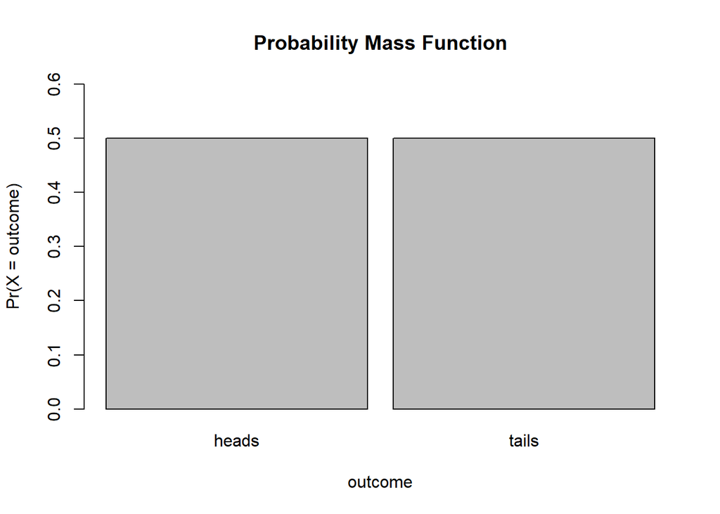

```r
outcomes <- c("heads","tails")
prob <- c(1/2,1/2)
barplot(prob,ylim=c(0,0.6),names.arg=outcomes,space=0.1, xlab="outcome",ylab="Pr(X = outcome)",main="Probability Mass Function")
```

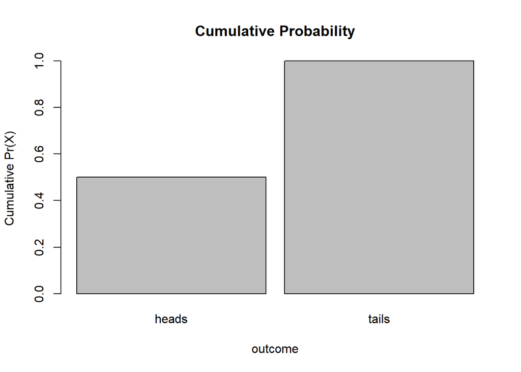

```r
cumprob <- cumsum(prob)
barplot(cumprob,names.arg=outcomes,space=0.1,xlab="outcome",ylab="Cumulative Pr(X)",main = "Cumulative Probability")
```

*Example: Rolling a Fair Die*

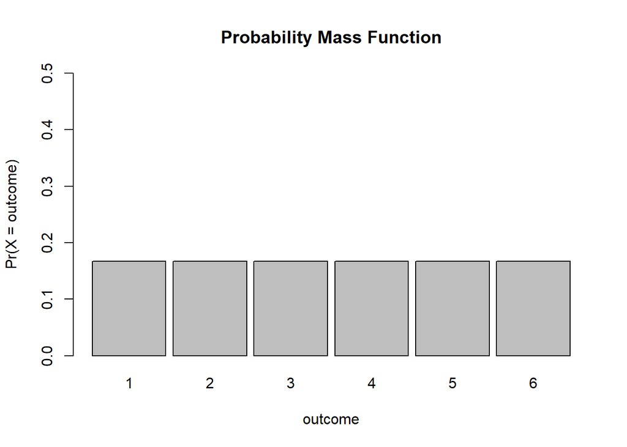

```r
outcomes <- c(1,2,3,4,5,6)
prob <- c(1/6,1/6,1/6,1/6,1/6,1/6)
barplot(prob,ylim=c(0,0.5),names.arg=outcomes,space=0.1,xlab="outcome",ylab="Pr(X = outcome)",main="Probability Mass Function")
```

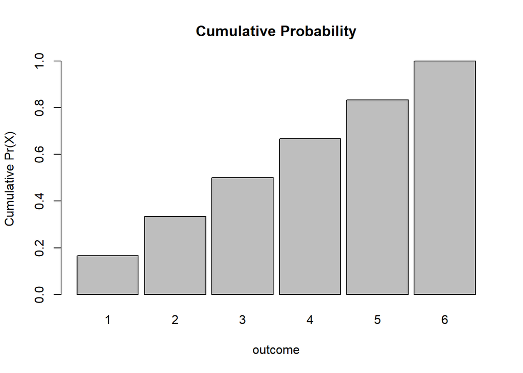

```r
cumprob <- cumsum(prob)
barplot(cumprob,names.arg=outcomes,space=0.1,xlab="outcome",ylab="Cumulative Pr(X)",main = "Cumulative Probability")
```

(Back to the two kinds of probabulity functions, the first being *PMFs*, the second being:)

2. *Probability Density Functions (PDFs)* are associated with continuous random variables. These functions describe the probability that a random variable falls within a given range of outcome values. The probability associated with that range equals the area under the density function for that range.

To be a valid *PDF*, a function *f(x)* must satisfy the following:

1. *f(x)* ≥ **0** for all −∞ ≤ *x* ≤ +∞. That is, the function *f(x)* is non-negative everywhere.
2. ∫<sup>+∞</sup><sub>−∞</sub> *f(x)* d*x* = **1**. That is, the total area under the function *f(x)* = **1**

*An Example*

The **Beta Distribution** refers to a family of continuous probability distributions defined over the interval [0, 1] and parametrized by two positive shape parameters, denoted by α and β, that appear as exponents of the random variable *x* and control the shape of the distribution.

**Formula**: *f(x)* = *K* *x*<sup>α−1</sup> (**1**−*x*)<sup>β−1</sup>

If we set **k** = 2, α = 2, and β = 1 and restrict the domain of *x* to [0, 1] it gices us a triangular function that we can graph as follows:

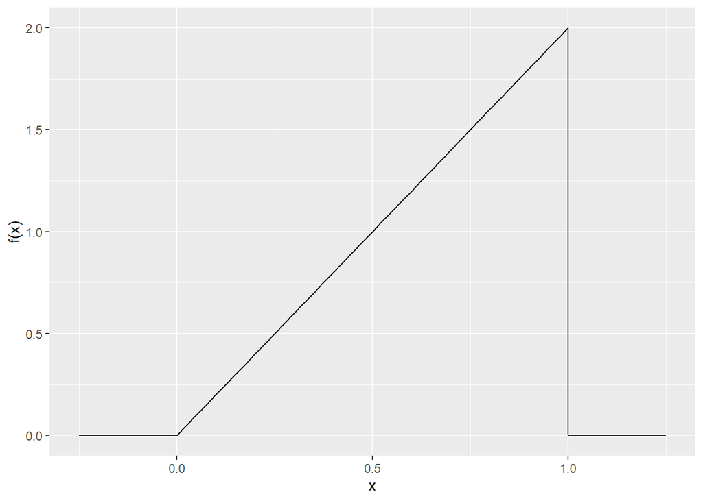

```r
library(ggplot2)
a <- 2
b <- 1
K <- 2
x <- seq(from= 0, to=1, by = 0.025)
fx <- K*x^(a-1)*(1-x)^(b-1)
lower_x <- seq(from=-0.25, to=0, by= 0.025) # add some values of x less than zero
upper_x <- seq(from=1, to=1.25, by= 0.025) # add some values of x greater than one
lower_fx <- rep(0,11) # add fx=0 values to x<0
upper_fx <- rep(0,11) # add fx=0 values to x>1
x <- c(lower_x,x,upper_x) # paste xs together
fx <- c(lower_fx,fx,upper_fx) # paste fxs together
d <- as.data.frame(cbind(x,fx))
p <- ggplot(data = d, aes(x=x, y=fx)) + xlab("x") + ylab("f(x)") + geom_line()
p
```

Is this a **PDF**? Why or why not?

*Yes!* It satisfies **both** criteria for a *PDF* (see above):

1. *f(x)* ≥ **0** for all −∞ ≤ *x* ≤ +∞.
2. ∫<sup>+∞</sup><sub>−∞</sub> *f(x)* d*x* = **1**

The **cumulative distribution function**, or **CDF**, of a random variable is defined as the probability of observing a random variable *X* taking the value of *x* or less, i.e., *F*(*x*) = *Pr*(*X* ≤ *x*).

[figure not shown]

```r
x <- seq(from=0, to=1, by=0.005)
prob <- 0.5 * x * K*x^(a-1)*(1-x)^(b-1)
barplot(prob,names.arg=x,space=0,main = "Cumulative Probability", xlab="x",ylab="Pr(X ≤ x)")
```

**IMPORTANT!** The built-in *R* function for the **Beta Distribution** [pbeta()], can give us the cumulative probability directly, if we specify values of α = 2 and β = 1.

```r
pbeta(0.75, 2, 1) # cumulative probability for x ≤ 0.75
```

```
## [1] 0.5625
```

We can define the **survival function** for a random variable *X* as **S**(*x*) = *Pr*(*X* > *x*) = 1 - *Pr*(*X* ≤ *x*) = 1 - *f*(*x*)

Finally, we can define the “qth” *quantile* of a *cumulative distibution function* as the value of *x* at which the *CDF* has the value “q”, i.e., *F*(*x*<sub>q</sub>) = *q*.

# Expected Mean and Variance of Random Variables

The **mean value** (or expectation) and the **expected variance** for a random variable with a given *probability mass function* can be expressed generally as follows:

μ<sub>*X*</sub> = Expectation for *X* = ∑ *x*<sub>i</sub> × *Pr*(*X* = *x*<sub>i</sub>) for all *x* from *x*<sub>i</sub> to *x*<sub>k</sub>

σ<sup>2</sup><sub>*X*</sub> = Variance of *X* = ∑ (*x*<sub>i</sub> − μ<sub>*X*</sub>)<sup>2</sup> × *Pr*(*X* = *x*<sub>i</sub>) for all *x* from *x*<sub>i</sub> to *x*<sub>k</sub>

Applying these formulas to die rolls, we could calculate the expectation for *X* for a large set of die rolls:

(1 * 1/6) + (2 * 1/6) + … + (6 * 1/6) = 3.5

```r
m <-sum(seq(1:6) * 1/6)
m
```

```
## [1] 3.5
```

And the expected variance:

[(1 - 3.5)^2 * (1/6)] + [(2 - 3.5)^2 * (1/6)] + … + [(6 - 3.5)^2 * (1/6)] =

```r
var <- sum((seq(1:6)-mean(seq(1:6)))^2 * (1/6))
var
```

```
## [1] 2.916667
```

Likewise, we can calculate the expectation and variance for a random variable *X* with a given *probability density function* generally as follows:

μ<sub>*X*</sub> = Expectation for *X* = ∫<sup>+∞</sup><sub>−∞</sub> *x* *f*(*x*) d*x*

σ<sup>2</sup><sub>*X*</sub> = Variance of *X* = ∫<sup>+∞</sup><sub>−∞</sub> (*x*−μ<sub>*X*</sub>)<sup>2</sup> *f*(*x*) d*x*

To demonstrate these numerically would require a bit of calculus, i.e., *integration*.

*…Skipping down to section that applies to HW #2…*

## **HOMEWORK:** *Poisson Distribution*

The **Poisson Distribution** is often used to model open ended counts of independently occuring events, for example the number of cars that pass a traffic intersection over a given interval of time or the number of times a monkey scratches itself during a given observation interval. The *probability mass function* for the Poisson distribution is described by a single parameter, λ, where λ can be interpreted as the mean number of occurrences of the event in the given interval.

The *probability mass function* for the **POISSON DISTRIBUTION** is:

(not able to put in exactly how Chris has it, but this is close)

*f*(*x*) = (λ<sup>2</sup> *exp* (-λ)) / *x*!

where *x* = {0, 1, 2, …}

For this distribution, μ<sub>*X*</sub> = λ and σ<sup>2</sup><sub>*X*</sub> = λ

For this distribution, μ<sub>*X*</sub> = λ and σ<sup>2</sup><sub>*X*</sub> = λ

THEREFORE, mean and the variance are the **SAME**! (see above for mean and variance equations)

Let’s use *R* to look at the probability mass functions for different values of λ (lamda):

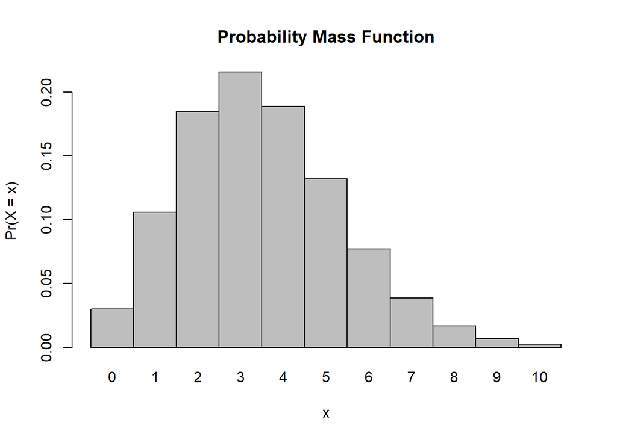

```r
x <- 0:10
l = 3.5 # l is lamda
probset<-dpois(x=x,lambda=l)
barplot(probset,names.arg=x,space=0,xlab="x",ylab="Pr(X = x)",main="Probability Mass Function")
```

Another example:

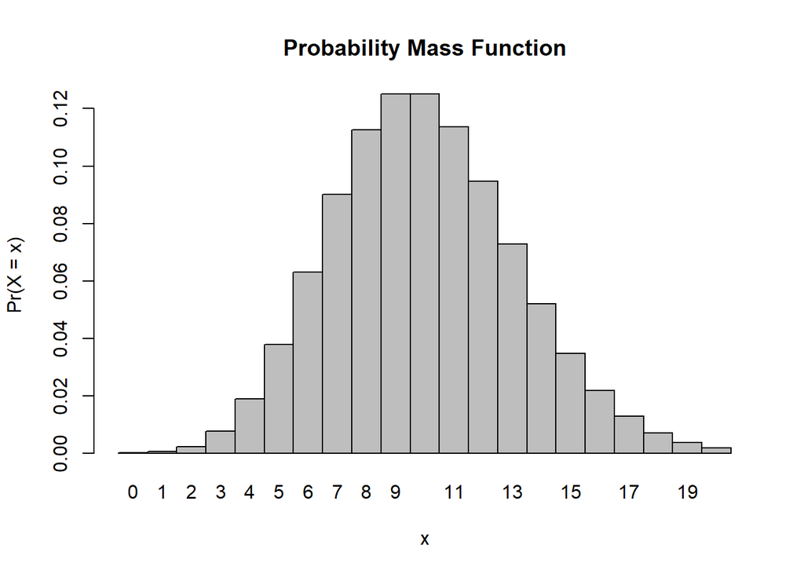

```r
x <- 0:20
l = 10
probset<-dpois(x=x,lambda=l)
barplot(probset,names.arg=x,space=0,xlab="x",ylab="Pr(X = x)",main="Probability Mass Function")
```

**IMPORTANT!** We can also use the built in probability function for the **Poisson Distribution**, ppois(), to return the value of the cumulative distributuion function, i.e., the probability of observing up to and including a specific number of events in the given interval.